# Tema 3

El presente tema expone la transformación de los datos. Se abordarán los puntos:

- La transformación y la carga.
- Los pipes.
- Verficar y cambiar los tipos de variables.
- Transformación del tipo de datos: crear, seleccionar, ordenar, agrupar, y otros elementos.
- Horientación de la data.
- Otros arreglos a la data.

Al finalizar la sesión se estará en completa capacidad para transformar cualquier archivo de datos, para próximamente analizar la información (tablas, gráficos, etc.).

# De vuelta al ETL…

Habíamos definido el ETL como:

**E**xtract, **T**ransform and **L**oad es el proceso que permite mover datos desde múltiples fuentes, reformatearlos y limpiarlos, y cargarlos en otra fuente de análisis: base de datos, data mart, o data warehouse, para luego analizarlos y darle un valor a la información.

[figure not shown]

El tema anterior nos encargamos del proceso de *Extract* o de extracción de la data. Se presentará ante todo el proceso de Transformación. Se explicará en que consiste el proceso de Carga.

## La transformación.

Entendemos por transformación una serie de arreglos o reglas para los datos extraídos, para así convertirlos en datos que serán cargados y luego analizados. Normalmente, las fuentes primarias (archivos planos) requerirán manipulación de los datos para poder calsar con la representación de análisis deseado.

Algunos casos de transformación podrían ser:

- Seleccionar solo ciertas columnas.
- Traducir códigos (por ejemplo, si la fuente almacena una “H” para Hombre y “M” para Mujer pero el destino tiene que guardar “1” para Hombre y “2” para Mujer).
- Codificar valores libres (por ejemplo, convertir “Hombre” en “H” o “Sr” en “1”).
- Obtener nuevos valores calculados (por ejemplo, total_venta = cantidad * precio, o Beneficio = PVP - Coste).
- Unir datos de múltiples fuentes (por ejemplo, búsquedas, combinaciones, etc.).
- Calcular totales de múltiples filas de datos (por ejemplo, ventas totales de cada región).
- Generación de campos clave en el destino.
- Transponer o pivotar (girando múltiples columnas en filas o viceversa).
- Dividir una columna en varias (por ejemplo, columna “Nombre: García López, Miguel Ángel”; pasar a tres columnas “Nombre: Miguel Ángel”, “Apellido1: García” y “Apellido2: López”).
- Entre otros.

Al finalizar la fase de transformación, manipulación de la data, poseemos el archivo deseado para el futuro análisis.

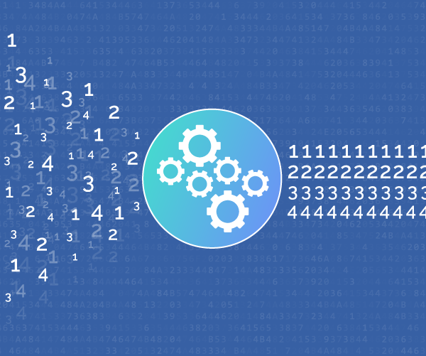

## La carga

La fase de carga es el momento en el cual los datos de la fase anterior (transformación) son cargados en el sistema de destino.

El presente curso no presente realmente la *carga*, dado que trabajamos siempre en nuetro “serviro local”, lo cual sería nuestro ordenador. Sin embargo, si el archivo fuera trasladado a otra computadora, servidor, etc, entonces el viaje del archivo a otro sistema, una vez este finalizado y adaptado al otro entorno, eso sería la carga.

[figure not shown]

# Los pipes.

Antes de iniciar el contenido de la transformación de los datos, hagamos un paréntesis y expliquemos el funcionamiento de los **pipes** en R.

El uso de los pipes es una de tantas alternativas en la transformación y tratamiento de los datos. Los utilizaremos dado que facilita bastante el proceso de transformación y en sí de expresar código sencillo en R.

Al hacer uso de estos, sería bueno explicar qué son, de dónde provienen, cuándo utilizarlos y cuando **NO** utilizarlos.

### ¿Qué son los pipes?

Los pipes son una herramienta poderosa para expresan una secuencia de operaciones en diversas funciones. Se utilizan tanto en el tratamiento, trasformación y otros relacionados con la data, como lo son la presentación tabular y gráfica, por ejemplo.

R Studio define así los *pipes*.

[figure not shown]

## ¿De dónde provienen?

Provienen de tres corrientes de pensamiento y de aplicación:

- Matemática
- Informática
- Programación en R

Fue creado por Stefan Bache, y propuesta bajo para la librería de *magrittr*. Más adelante fue incorporado en la librería *dplyr* dado que *magrittr* es una dependencia de esta.

¿Qué queremos decir con que *magrittr* es una dependencia de la librería *dplyr*?

Por ende, ¿qué entendemos por depedencia de una librería?

Para utilizar el pipe debemos, por lo tanto, utilizar alguna de las siguientes librerías

```r
suppressWarnings(library(magrittr))
suppressWarnings(library(dplyr))
```

Cargas las librerías, podemos utilizar el operador *pipe*.

```r
%>%
```

## ¿Cómo funciona?

El operador *pipe* es un desencadenador de comandos en uno o varias funciones en específico. Se podría decir que el operador es una forma de decir, a este objeto, realize esto, luego a este otro haga esto sabiendo que hizo aquello, y así consecutivamente.

Para aclarar, veamos un ejemplo a partir del set de datos “data”.

Recordemos un poco este set de datos.

```r
names(data)
```

```
##  [1] "Id"           "ano"          "fecha"        "ingreso1"     "ingreso2"
##  [6] "ingreso3"     "ingreso4"     "ingreso5"     "Sexo"         "Estadocivil"
## [11] "Trabajador"   "Nacionalidad" "Sangre"       "logica"
```

```r
head(data)
```

```
## # A tibble: 6 x 14
##      Id   ano fecha               ingreso1 ingreso2 ingreso3 ingreso4 ingreso5
##   <dbl> <dbl> <dttm>                 <dbl>    <dbl>    <dbl>    <dbl>    <dbl>
## 1  1001  2018 2018-01-01 00:00:00     6432     8715     5028     1305     4265
## 2  1002  2018 2018-01-02 00:00:00     8494     7370     3066     2180     7449
## 3  1003  2018 2018-01-03 00:00:00     9529     1936     5597     2398     4697
## 4  1004  2018 2018-01-04 00:00:00     9565     1513     4609     1674     9828
## 5  1005  2018 2018-01-05 00:00:00     4061     6501     3367     3283     7437
## 6  1006  2018 2018-01-06 00:00:00     3137     4938     2294     1515     8726
## # ... with 6 more variables: Sexo <chr>, Estadocivil <dbl>, Trabajador <dbl>,
## #   Nacionalidad <dbl>, Sangre <chr>, logica <chr>
```

Vamos a manipular o hacer una pequeña transformación a nuestros archivo *data*. Veamos el uso de los *pipes* en la asignación de un nuevo archivo llama *datos*:

```r
datos <- data %>%
           filter(ingreso1 > 4000) %>%
           arrange(ingreso1)

head(datos[,], n=10)
```

```
## # A tibble: 10 x 14
##       Id   ano fecha               ingreso1 ingreso2 ingreso3 ingreso4 ingreso5
##    <dbl> <dbl> <dttm>                 <dbl>    <dbl>    <dbl>    <dbl>    <dbl>
##  1  1125  2018 2018-05-05 00:00:00     4015     3191     3880     8864     9010
##  2  1379  2019 2019-01-14 00:00:00     4029     5930     1719     3313     5588
##  3  1840  2020 2020-04-19 00:00:00     4029     7276     2347     7966     3774
##  4  1022  2018 2018-01-22 00:00:00     4032     3510     7020     9826     4341
##  5  1914  2020 2020-07-02 00:00:00     4040     3318     2551     8168     3056
##  6  1992  2020 2020-09-18 00:00:00     4057     9930     3194     6806     5966
##  7  1194  2018 2018-07-13 00:00:00     4058     8833     6394     9066     1628
##  8  1005  2018 2018-01-05 00:00:00     4061     6501     3367     3283     7437
##  9  1797  2020 2020-03-07 00:00:00     4082     3528     2772     7532     6489
## 10  1858  2020 2020-05-07 00:00:00     4082     9083     7567     9753     5251
## # ... with 6 more variables: Sexo <chr>, Estadocivil <dbl>, Trabajador <dbl>,
## #   Nacionalidad <dbl>, Sangre <chr>, logica <chr>
```

¿Qué fue lo que sucedió?

A partir del archivo **data**, filtramos todo el set de datos según la variable *ingresos1* donde solo los ingresos superiores a 4000 pueden figurar. Luego, ordenamos de menor a mayor el set de **datos** tomando la variable *ingresos* como referencia.

¿Cómo se debería leer o interpretar el uso del pipe?

De la siguiente manera:

**bajo la asignacion de datos, primero tome el set “data”, luego realice un filtro “ingresos1” > 4000, luego de esto realice un ordenamiento sabiendo o manteniendo en memoria lo anterior**

Una forma más expedita de explicarlo:

**…tome el set datos, luego realice un filtro para “ingresos1>4000”, y luego ordene de menos a más por “ingresos”.**

El uso del pipe %>% es una forma rápida y expedita de transformar, resumir y hacer diversas operaciones a la información.

El proceso de tener una cadena estandarizada de acciones de procesamiento se le conoce como realizar **pipelines** a la data o a la información.

Veamos la siguiente definición de **pipelines**:

*Data pipelines enable the flow of data from an application to a data warehouse, from a data lake to an analytics database, or into a payment processing system, for example.* **Data pipelines also may have the same source and sink, such that the pipeline is purely about modifying the data set.**

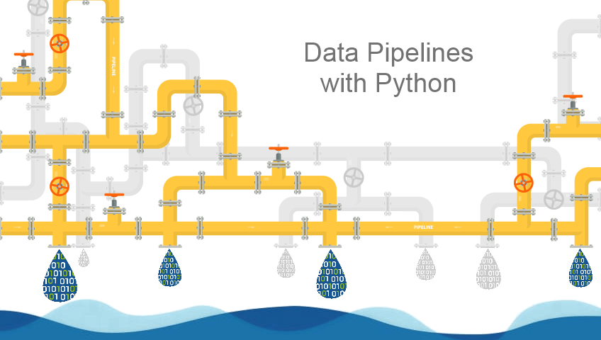

## ¿Por qué utilizar los pipes?

R es un lenguaje funcional, lo que significa que su código a menudo contiene muchos argumentos dentro de su función, o dentro del paréntesis de la función **( )**.

Cuando se posee un código complejo, esto a menudo significa que se tendrá que anidar diversos paréntesis **(…(( ))…)** para una solicitud determinada.

Esto hace que el código R sea muchas veces difícil de leer y comprender…

¡Pero aquí es donde nuestros *pipes* **%>%** entra al rescate de nosotros! (… un poco polo pero la idea se endiende XD …)

Veamos el siguiente ejemplo, el cuál explica el caso anterior:

```r
# Creamos el vector  "x"

x <- c(0.109, 0.359, 0.63, 0.996, 0.515, 0.142, 0.017, 0.829, 0.907)
```

Queremos para el vector x, el logaritmo de la diferencia exponenciada y redondeado al entero 1 más próximo. Aplicamos las siguientes funciones al vector *x*:

- round
- exp
- diff
- log

Para lo que requerimos, su expresión en funciones anidadas sería lo siguiente:

```r
round(exp(diff(log(x))), 1)
```

```
## [1]  3.3  1.8  1.6  0.5  0.3  0.1 48.8  1.1
```

Puede llegar a ser complicado… dado que son muchas funciones anidadas entre sí. Además nótese que el ordenamiento de cada funciones debe ir con cuidado… controlar tantos paréntesis suele ser un trabajo molesto.

¡Con el uso uso del pipe se hace mucho más sencillo!

Veamos la siguiente aplicación:

```r
library(magrittr)

x %>% log() %>%
    diff() %>%
    exp() %>%
    round(1)
```

```
## [1]  3.3  1.8  1.6  0.5  0.3  0.1 48.8  1.1
```

Obtenemos los mismos resultados.

También tenga en cuenta que **NO** es un requisito formal agregar los paréntesis después del *log*, *diff* y *exp*, pero, dentro de la comunidad de R, se prefiere ponerlos para aumentar la legibilidad del código.

Entre las principales razones para utilizar el pipe tenemos:

- Estructurará la secuencia de sus operaciones de datos de izquierda a derecha, como se indica desde adentro hacia afuera.
- Evitará hacer uso de funciones anidadas.
- Minimizará la necesidad de variables locales y definiciones de funciones.
- Facilitará agregar niveles o pasos en cualquier lugar de la secuencia de las operaciones.

## Cuándo no usar los pipes

El pipe (¿los pipes?) es (son) una herramienta poderosa, pero no es la única herramienta a disposición, y no resuelve todos los problemas… Los pipes son más útiles para reescribir una secuencia lineal de operaciones bastante cortas. Se deberían buscar otra herramienta cuando:

- Los pipes son más largos que, digamos, diez pasos. En ese caso, cree objetos intermedios con nombres significativos. Eso facilitará la depuración, ya que puede verificar más fácilmente los resultados intermedios y facilita la comprensión de su código, porque los nombres de las variables pueden ayudar a comunicar la intención.
- Existen múltiples entradas o salidas. Si no hay un objeto primario que se está transformando, pero dos o más objetos se combinan entre sí, no use la tubería.
- Está comenzando a pensar en un gráfico dirigido con una estructura de dependencia compleja. Las tuberías son fundamentalmente lineales y expresar relaciones complejas con ellas generalmente generará un código confuso.

No todo esto es del todo claro, pero está fuera de los propósitos del curso.

Para más imformación de los pipes, véase el siguiente enlace:

https://www.datacamp.com/community/tutorials/pipe-r-tutorial

# Transformación de los datos.

Ahora sí! Manos a la obra!

Adquirido el conocimiento sobre los *pipes*, volvemos a la *Matrix* para hacer todas las modificaciones que deseemos.

[figure not shown]

El proceso de transformación es muy amplio, y abarca temas como:

- Asignación correcta de las variables.
- Seleccionar las variables y casos necesarios.
- Crear nuevas variables.
- Imputación de los NA (valores perdidos).
- Cambiar la estructura u orientacion del archivo de datos.
- Entre otros….

En el presente tema trataremos de estudiar la mayor de herramientas que se suelen utilizar en la transformación de los datos.

Surgirá la pregunta: ¿por qué deberé comenzar?

Esa preguna es complicada de responder. Cada persona tiene su estilo y su forma de arreglar los datos. Una aproximación muy acertada es ver qué procesos permite optimizar el proceso como tal, pero es algo que está fuera del contenido del presente curso.

El proceso de transformación se crea para, a partir de un archivo de datos, limpiarlo o transformalo, para luego obtener los partes que nos intereza. Por tanto deter un archivo totalmente restituido es vital para los análisis a venir.

# Cambiando el tipo de variable.

¿Recuerdan el proceso de importación de la clase anterior? ¿Recuerdan que habían variables que, a la hora de la importación, no recibián correctamente el tipo que realmente les correspondia?

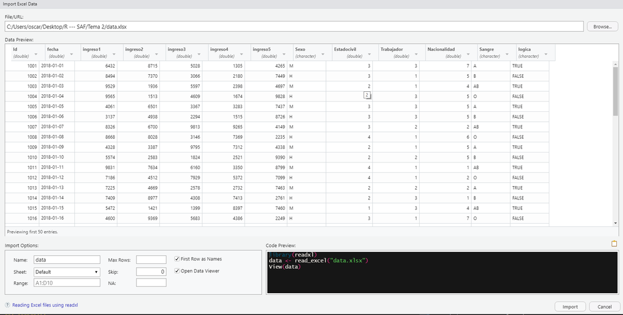

Una etapa importante de la transformación y arreglo del archivo de datos, es corroborar que efectivamente los datos posean el tipo que les corresponde. Después de todo, los datos, nuestra matería prima, debe contener el valor que realmente les pertenece.

Se podrían preguntar: ¿pero no fue cubierto en la importar? La respuesta es un rotundo **SÍ**, pero muchas veces lo obviamos, y pues no toca transformarlo luego de la importanción de los datos. Por cierto, la opción de importar por el *ide* de R posee la opción de cambiar el tipo de variable, así como la sintaxis de importación de datos.

De igual manera, cuando no estamos familiarizados con los datos, no nos queda de otra que hacer el arreglo luego de la etapa de la importación de la data. Veamos el caso de nuestro archivo llamado data.

```r
names(data)
```

```
##  [1] "Id"           "ano"          "fecha"        "ingreso1"     "ingreso2"
##  [6] "ingreso3"     "ingreso4"     "ingreso5"     "Sexo"         "Estadocivil"
## [11] "Trabajador"   "Nacionalidad" "Sangre"       "logica"
```

```r
suppressWarnings(data)
```

```
## # A tibble: 1,000 x 14
##       Id   ano fecha               ingreso1 ingreso2 ingreso3 ingreso4 ingreso5
##    <dbl> <dbl> <dttm>                 <dbl>    <dbl>    <dbl>    <dbl>    <dbl>
##  1  1001  2018 2018-01-01 00:00:00     6432     8715     5028     1305     4265
##  2  1002  2018 2018-01-02 00:00:00     8494     7370     3066     2180     7449
##  3  1003  2018 2018-01-03 00:00:00     9529     1936     5597     2398     4697
##  4  1004  2018 2018-01-04 00:00:00     9565     1513     4609     1674     9828
##  5  1005  2018 2018-01-05 00:00:00     4061     6501     3367     3283     7437
##  6  1006  2018 2018-01-06 00:00:00     3137     4938     2294     1515     8726
##  7  1007  2018 2018-01-07 00:00:00     8326     6700     9813     9265     4149
##  8  1008  2018 2018-01-08 00:00:00     8668     8028     3146     7369     2235
##  9  1009  2018 2018-01-09 00:00:00     4328     3387     9795     7312     4338
## 10  1010  2018 2018-01-10 00:00:00     5574     2583     1824     2521     9390
## # ... with 990 more rows, and 6 more variables: Sexo <chr>, Estadocivil <dbl>,
## #   Trabajador <dbl>, Nacionalidad <dbl>, Sangre <chr>, logica <chr>
```

¿Qué percibimos para las diferentes variables? ¿Todas están correctamente asignadas?

Veamos la estructura del archivo data:

```r
str(data)
```

```
## tibble [1,000 x 14] (S3: tbl_df/tbl/data.frame)
##  $ Id          : num [1:1000] 1001 1002 1003 1004 1005 ...
##  $ ano         : num [1:1000] 2018 2018 2018 2018 2018 ...
##  $ fecha       : POSIXct[1:1000], format: "2018-01-01" "2018-01-02" ...
##  $ ingreso1    : num [1:1000] 6432 8494 9529 9565 4061 ...
##  $ ingreso2    : num [1:1000] 8715 7370 1936 1513 6501 ...
##  $ ingreso3    : num [1:1000] 5028 3066 5597 4609 3367 ...
##  $ ingreso4    : num [1:1000] 1305 2180 2398 1674 3283 ...
##  $ ingreso5    : num [1:1000] 4265 7449 4697 9828 7437 ...
##  $ Sexo        : chr [1:1000] "M" "H" "M" "H" ...
##  $ Estadocivil : num [1:1000] 3 3 2 2 3 3 3 4 2 2 ...
##  $ Trabajador  : num [1:1000] 3 1 1 3 3 3 2 1 1 2 ...
##  $ Nacionalidad: num [1:1000] 7 5 4 5 5 5 2 6 5 5 ...
##  $ Sangre      : chr [1:1000] "A" "B" "AB" "O" ...
##  $ logica      : chr [1:1000] "TRUE" "FALSE" "TRUE" "FALSE" ...
```

¿Cuáles son las variables que deberíamos entonces modificar?

## Tipos de variable

Antes de estudiar cómo es que modificamos el tipo de variables, veamos dos funciones útiles para corrobor el tipo de datos.

### La función class()

Mediante la función class() podemos ver qué es cada objeto: escalar, vector, matriz, archivo y aún más…

```r
class(data)
```

```
## [1] "tbl_df"     "tbl"        "data.frame"
```

Y si, todo es **TODO**.

```r
class(data$Id)
```

```
## [1] "numeric"
```

```r
class(data$fecha)
```

```
## [1] "POSIXct" "POSIXt"
```

```r
class(data$ingreso1)
```

```
## [1] "numeric"
```

```r
class(data$ingreso2)
```

```
## [1] "numeric"
```

```r
class(data$ingreso3)
```

```
## [1] "numeric"
```

```r
class(data$ingreso4)
```

```
## [1] "numeric"
```

```r
class(data$ingreso5)
```

```
## [1] "numeric"
```

```r
class(data$Sexo)
```

```
## [1] "character"
```

```r
class(data$Estadocivil)
```

```
## [1] "numeric"
```

```r
class(data$Trabajador)
```

```
## [1] "numeric"
```

```r
class(data$Nacionalidad)
```

```
## [1] "numeric"
```

```r
class(data$Sangre)
```

```
## [1] "character"
```

```r
class(data$logica)
```

```
## [1] "character"
```

### La familia de funcion “is.TIPO()”

Otra forma es mediante la familia de “is.TIPO()”, por ejemplo **is.numeric()**, **is.character()**, etc.

Acá tenemos diversas modalidades:

```r
is.array()
is.atomic()
is.call()
is.character()
is.complex()
is.data.frame()
is.na.data.frame()
is.double()
is.element()
is.environment()
is.expression()
is.factor()
#is.  --> y se despliega la lista entera
```

Veamos su uso:

```r
is.character(data$Id)
```

```
## [1] FALSE
```

```r
class(data$fecha)
```

```
## [1] "POSIXct" "POSIXt"
```

```r
is.character(data$Sexo)
```

```
## [1] TRUE
```

```r
is.character(data$Estadocivil)
```

```
## [1] FALSE
```

```r
is.character(data$Trabajador)
```

```
## [1] FALSE
```

```r
is.character(data$Nacionalidad)
```

```
## [1] FALSE
```

```r
is.character(data$Sangre)
```

```
## [1] TRUE
```

```r
is.logical(data$logica)
```

```
## [1] FALSE
```

El uso de la función “is.*TIPO*()” devuelve un valor lógico, y mediante los valores **TRUE** o **FALSE**, nos guía en la asignación correcta de las variables.

## Cambiando las variables

Ahora que sabemos que debemos trabajar con la asignación correcta de cada columna (o su tipo), existen dos formas de modificar las variables según el tipo que les corresponda:

- Método clásico
- Utilizando el dplyr

Veamos ambas modalidades

### A la antigua…

La primera era utilizando una función llamada “as.*TIPO*()”. Por ejemplo **as.numecir()**, o **as.character()**.

Veamos esto traducido a código R.

```r
data
```

```
## # A tibble: 1,000 x 14
##       Id   ano fecha               ingreso1 ingreso2 ingreso3 ingreso4 ingreso5
##    <dbl> <dbl> <dttm>                 <dbl>    <dbl>    <dbl>    <dbl>    <dbl>
##  1  1001  2018 2018-01-01 00:00:00     6432     8715     5028     1305     4265
##  2  1002  2018 2018-01-02 00:00:00     8494     7370     3066     2180     7449
##  3  1003  2018 2018-01-03 00:00:00     9529     1936     5597     2398     4697
##  4  1004  2018 2018-01-04 00:00:00     9565     1513     4609     1674     9828
##  5  1005  2018 2018-01-05 00:00:00     4061     6501     3367     3283     7437
##  6  1006  2018 2018-01-06 00:00:00     3137     4938     2294     1515     8726
##  7  1007  2018 2018-01-07 00:00:00     8326     6700     9813     9265     4149
##  8  1008  2018 2018-01-08 00:00:00     8668     8028     3146     7369     2235
##  9  1009  2018 2018-01-09 00:00:00     4328     3387     9795     7312     4338
## 10  1010  2018 2018-01-10 00:00:00     5574     2583     1824     2521     9390
## # ... with 990 more rows, and 6 more variables: Sexo <chr>, Estadocivil <dbl>,
## #   Trabajador <dbl>, Nacionalidad <dbl>, Sangre <chr>, logica <chr>
```

```r
class(data$Id)
```

```
## [1] "numeric"
```

```r
#as.character(data$Id)
class(as.character(data$Id))
```

```
## [1] "character"
```

```r
data$Id = as.character(data$Id)

tail(data)
```

```
## # A tibble: 6 x 14
##   Id      ano fecha               ingreso1 ingreso2 ingreso3 ingreso4 ingreso5
##   <chr> <dbl> <dttm>                 <dbl>    <dbl>    <dbl>    <dbl>    <dbl>
## 1 1995   2020 2020-09-21 00:00:00     8563     5257     4632     4881     7976
## 2 1996   2020 2020-09-22 00:00:00     4301     9740     9516     9980     8554
## 3 1997   2020 2020-09-23 00:00:00     6120     8358     3418     6264     2190
## 4 1998   2020 2020-09-24 00:00:00     1752     6195     6655     9014     1087
## 5 1999   2020 2020-09-25 00:00:00     7199     8458     2294     5119     4586
## 6 2000   2020 2020-09-26 00:00:00     9291     7164     8415     4993     4239
## # ... with 6 more variables: Sexo <chr>, Estadocivil <dbl>, Trabajador <dbl>,
## #   Nacionalidad <dbl>, Sangre <chr>, logica <chr>
```

```r
class(data$Id)
```

```
## [1] "character"
```

Utilizamos dos elementos : la función *as.characte()* (**derecha**), y la referencia a la variable que debemos cambiar (**izquierda**).

Otro aspecto interesante es que **NO** utilizamos el signo “*<-*” si no el “**=**” Resulta que podemos crear escalares, matrices , vectores y otros con el signo “=”, pero lo recomdable es utilizar el signo “**=**” en espacio de condicionamiento o de asginación exclusiva, como es el caso.

¿Por qué decirmos asignación exclusiva? …

¿Qué hubiera pasado si en vez de usar “**=**” utilozamos el signo “<-” ? Eso lo deben probar por aparte.

Hay diversas funciones “as.*TIPO*()”:

```r
as.array()
as.character()
as.Date()
as.factor()
as.null()
as.numeric()
```

## Mediante el uso del dplyr

Podemos modificar los tipos de variables mediante las siguientes funciones del dplyr:

- mutate: crea una variable función.
- transmutate: re escribe la variable.

Especificado esto, igualemente volveríamos a la forma vista anteriormete de:

```r
datos$variable = as.TIPO(datos$variable)
```

Cuando estemos en la sección de Transformación de variables –> Creando nuevas variables, veremos las modalidas comentadas.

# Operadores condicionales.

Antes seguir estudiante otras formas de transformar la información, se debe explicar los tipos de **Operadores condicionales**.

En la definición y transformación de los datos, necesitaremos utilizar ciertos operadores. Una lista de los más utilizados:

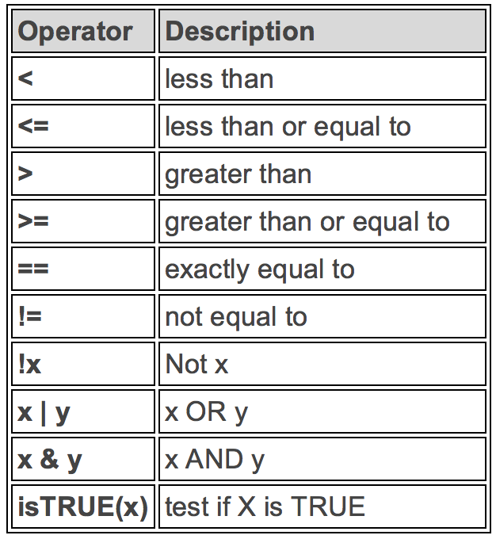

Veremos luego como aplicamos varios de estos operadores.

# Transformación de los datos.

Al analizar la información, gran parte del tiempo se consume en arreglar el archivos de datos. Procesos tales como filtrar, ordenar, eliminar, crear nuevas variables, etc., son catalogadas como proceso de transformación.

Además de la correcta asignación de variables, podemos tener tres grandes tipos de transformación:

- Para las varibles (columnas).
- Para los casos (líneas).
- Para todo el archivo de datos (rectángulos).

Presentaremos estos casos.

Utilizaremos para esto la librería de **dplyr** de R.

```r
library(dplyr)
```

[figure not shown]

## Manipulando casos

Al manipular casos, algunas de las funciones que podríamos uilizar son:

- **filter**: filtra o extrae cierta casos según algún criterio condicional
- **distinct**: elimina columnas con casos duplicados
- **sample_frac**: de forma aleatoria selecciona según la fracción un número de casos
- **sample_n**: de forma aleatoria selecciona una muestra de tamaño n de casos
- **slice**: selecciona casos o columnas según la posición
- **arrange**: ordena los casos según algún criterio
- **add_row**: permite agregar uno o más casos al archivo de datos

Las funciones **mutate()** y **transmutate()** tendrán un apartado especial, cuando veamos la creación de varibles.

Veamos las funciones más representativas.

### Filter()

```r
dim(data)
```

```
## [1] 1000   14
```

```r
# solo por esta ver haremos una asignación

a <- data  %>%
     dplyr::filter(data$Sexo=="M")

dim(a)
```

```
## [1] 500  14
```

```r
b <- data  %>%
     dplyr::filter(data$ingreso1>6000)

dim(b)
```

```
## [1] 435  14
```

### distinct()

```r
#Opción 1
 data  %>%
     dplyr::distinct(data$Sexo)
```

```
## # A tibble: 2 x 1
##   `data$Sexo`
##   <chr>
## 1 M
## 2 H
```

### sample_frac()

```r
dim(iris)
```

```
## [1] 150   5
```

```r
c <-  sample_frac(iris, 0.5) # opción replace=TRUE o replace=FALSE
dim(c)
```

```
## [1] 75  5
```

### sample_n()

```r
dim(iris)
```

```
## [1] 150   5
```

```r
d <- sample_n(iris, 30) # opción replace=TRUE o replace=FALSE
dim(d)
```

```
## [1] 30  5
```

### slice()

```r
dim(iris)
```

```
## [1] 150   5
```

```r
e <- slice(iris,40:90)
```

### El arrange()

El arrange o el ordenamiento puede hacer tanto ascendente (de menos a más) o descendente (de más a menos), además se pude ordenar por diversas variables.

```r
f1<- data  %>%
     dplyr::arrange(data,ingreso1)

f2<- data  %>%
    dplyr::arrange(data,desc(ingreso1))

f3 <- data  %>%
    dplyr::arrange(data,desc(ingreso1),ingreso2)
```

## Manipulando variables - columnas

Otra transformación fundamental es a nivel de las variables. Algunas de las funciones que se podrían utilizar son:

- **pull**: extrae los valors de la columna como si fue un vector. No extrae la columna de forma entera.
- **select**: selecciona la columna o variable.
- **rename**: le brinda otro nombre a la variable.
- **add_column**: agrega una columna.

Veamos un poco los usos a partir del archivo de datos *mtcars*:

```r
mtcars
```

```
##                      mpg cyl  disp  hp drat    wt  qsec vs am gear carb
## Mazda RX4           21.0   6 160.0 110 3.90 2.620 16.46  0  1    4    4
## Mazda RX4 Wag       21.0   6 160.0 110 3.90 2.875 17.02  0  1    4    4
## Datsun 710          22.8   4 108.0  93 3.85 2.320 18.61  1  1    4    1
## Hornet 4 Drive      21.4   6 258.0 110 3.08 3.215 19.44  1  0    3    1
## Hornet Sportabout   18.7   8 360.0 175 3.15 3.440 17.02  0  0    3    2
## Valiant             18.1   6 225.0 105 2.76 3.460 20.22  1  0    3    1
## Duster 360          14.3   8 360.0 245 3.21 3.570 15.84  0  0    3    4
## Merc 240D           24.4   4 146.7  62 3.69 3.190 20.00  1  0    4    2
## Merc 230            22.8   4 140.8  95 3.92 3.150 22.90  1  0    4    2
## Merc 280            19.2   6 167.6 123 3.92 3.440 18.30  1  0    4    4
## Merc 280C           17.8   6 167.6 123 3.92 3.440 18.90  1  0    4    4
## Merc 450SE          16.4   8 275.8 180 3.07 4.070 17.40  0  0    3    3
## Merc 450SL          17.3   8 275.8 180 3.07 3.730 17.60  0  0    3    3
## Merc 450SLC         15.2   8 275.8 180 3.07 3.780 18.00  0  0    3    3
## Cadillac Fleetwood  10.4   8 472.0 205 2.93 5.250 17.98  0  0    3    4
## Lincoln Continental 10.4   8 460.0 215 3.00 5.424 17.82  0  0    3    4
## Chrysler Imperial   14.7   8 440.0 230 3.23 5.345 17.42  0  0    3    4
## Fiat 128            32.4   4  78.7  66 4.08 2.200 19.47  1  1    4    1
## Honda Civic         30.4   4  75.7  52 4.93 1.615 18.52  1  1    4    2
## Toyota Corolla      33.9   4  71.1  65 4.22 1.835 19.90  1  1    4    1
## Toyota Corona       21.5   4 120.1  97 3.70 2.465 20.01  1  0    3    1
## Dodge Challenger    15.5   8 318.0 150 2.76 3.520 16.87  0  0    3    2
## AMC Javelin         15.2   8 304.0 150 3.15 3.435 17.30  0  0    3    2
## Camaro Z28          13.3   8 350.0 245 3.73 3.840 15.41  0  0    3    4
## Pontiac Firebird    19.2   8 400.0 175 3.08 3.845 17.05  0  0    3    2
## Fiat X1-9           27.3   4  79.0  66 4.08 1.935 18.90  1  1    4    1
## Porsche 914-2       26.0   4 120.3  91 4.43 2.140 16.70  0  1    5    2
## Lotus Europa        30.4   4  95.1 113 3.77 1.513 16.90  1  1    5    2
## Ford Pantera L      15.8   8 351.0 264 4.22 3.170 14.50  0  1    5    4
## Ferrari Dino        19.7   6 145.0 175 3.62 2.770 15.50  0  1    5    6
## Maserati Bora       15.0   8 301.0 335 3.54 3.570 14.60  0  1    5    8
## Volvo 142E          21.4   4 121.0 109 4.11 2.780 18.60  1  1    4    2
```

```r
names(mtcars)
```

```
##  [1] "mpg"  "cyl"  "disp" "hp"   "drat" "wt"   "qsec" "vs"   "am"   "gear"
## [11] "carb"
```

### pull()

```r
mtcars %>%
     pull(var = cyl)
```

```
##  [1] 6 6 4 6 8 6 8 4 4 6 6 8 8 8 8 8 8 4 4 4 4 8 8 8 8 4 4 4 8 6 8 4
```

```r
mtcars %>%
        select(cyl)
```

```
##                     cyl
## Mazda RX4             6
## Mazda RX4 Wag         6
## Datsun 710            4
## Hornet 4 Drive        6
## Hornet Sportabout     8
## Valiant               6
## Duster 360            8
## Merc 240D             4
## Merc 230              4
## Merc 280              6
## Merc 280C             6
## Merc 450SE            8
## Merc 450SL            8
## Merc 450SLC           8
## Cadillac Fleetwood    8
## Lincoln Continental   8
## Chrysler Imperial     8
## Fiat 128              4
## Honda Civic           4
## Toyota Corolla        4
## Toyota Corona         4
## Dodge Challenger      8
## AMC Javelin           8
## Camaro Z28            8
## Pontiac Firebird      8
## Fiat X1-9             4
## Porsche 914-2         4
## Lotus Europa          4
## Ford Pantera L        8
## Ferrari Dino          6
## Maserati Bora         8
## Volvo 142E            4
```

¿En dónde radica la diferencia entre el *pull()* y el *select()* ?

### select()

```r
mtcars %>%
        dplyr::select(cyl)
```

```
##                     cyl
## Mazda RX4             6
## Mazda RX4 Wag         6
## Datsun 710            4
## Hornet 4 Drive        6
## Hornet Sportabout     8
## Valiant               6
## Duster 360            8
## Merc 240D             4
## Merc 230              4
## Merc 280              6
## Merc 280C             6
## Merc 450SE            8
## Merc 450SL            8
## Merc 450SLC           8
## Cadillac Fleetwood    8
## Lincoln Continental   8
## Chrysler Imperial     8
## Fiat 128              4
## Honda Civic           4
## Toyota Corolla        4
## Toyota Corona         4
## Dodge Challenger      8
## AMC Javelin           8
## Camaro Z28            8
## Pontiac Firebird      8
## Fiat X1-9             4
## Porsche 914-2         4
## Lotus Europa          4
## Ford Pantera L        8
## Ferrari Dino          6
## Maserati Bora         8
## Volvo 142E            4
```

```r
mtcars %>%
        dplyr::select(cyl,disp,hp)
```

```
##                     cyl  disp  hp
## Mazda RX4             6 160.0 110
## Mazda RX4 Wag         6 160.0 110
## Datsun 710            4 108.0  93
## Hornet 4 Drive        6 258.0 110
## Hornet Sportabout     8 360.0 175
## Valiant               6 225.0 105
## Duster 360            8 360.0 245
## Merc 240D             4 146.7  62
## Merc 230              4 140.8  95
## Merc 280              6 167.6 123
## Merc 280C             6 167.6 123
## Merc 450SE            8 275.8 180
## Merc 450SL            8 275.8 180
## Merc 450SLC           8 275.8 180
## Cadillac Fleetwood    8 472.0 205
## Lincoln Continental   8 460.0 215
## Chrysler Imperial     8 440.0 230
## Fiat 128              4  78.7  66
## Honda Civic           4  75.7  52
## Toyota Corolla        4  71.1  65
## Toyota Corona         4 120.1  97
## Dodge Challenger      8 318.0 150
## AMC Javelin           8 304.0 150
## Camaro Z28            8 350.0 245
## Pontiac Firebird      8 400.0 175
## Fiat X1-9             4  79.0  66
## Porsche 914-2         4 120.3  91
## Lotus Europa          4  95.1 113
## Ford Pantera L        8 351.0 264
## Ferrari Dino          6 145.0 175
## Maserati Bora         8 301.0 335
## Volvo 142E            4 121.0 109
```

### rename()

```r
names(mtcars)
```

```
##  [1] "mpg"  "cyl"  "disp" "hp"   "drat" "wt"   "qsec" "vs"   "am"   "gear"
## [11] "carb"
```

```r
g <- mtcars %>%
        dplyr::rename(
          `Millas por galon`      = mpg,
          `Número de cilindros`   = cyl,
          `Caballos de fuerza`    = hp
        )

names(g)
```

```
##  [1] "Millas por galon"    "Número de cilindros" "disp"
##  [4] "Caballos de fuerza"  "drat"                "wt"
##  [7] "qsec"                "vs"                  "am"
## [10] "gear"                "carb"
```

¿Qué son los `` utilizados?

## Creando nuevas variables

Al crear nuevas variables solemos utilizar las funciones *mutate* y *transmutate*:

- **mutate**: crea una nueva variable, sin elminar las otras.
- **transmutate**: re escribe una variable y además elimina las demás variable

Veamos unos ejemplos:

### La función mutate

```r
dim(mtcars)
```

```
## [1] 32 11
```

```r
names(mtcars)
```

```
##  [1] "mpg"  "cyl"  "disp" "hp"   "drat" "wt"   "qsec" "vs"   "am"   "gear"
## [11] "carb"
```

```r
h <- mtcars %>%
         mutate(
             cyl_reloaded = cyl+4,
             mpg_reloaded = mpg/2

         )

dim(h)
```

```
## [1] 32 13
```

```r
names(h)
```

```
##  [1] "mpg"          "cyl"          "disp"         "hp"           "drat"
##  [6] "wt"           "qsec"         "vs"           "am"           "gear"
## [11] "carb"         "cyl_reloaded" "mpg_reloaded"
```

```r
h[,c("cyl_reloaded","mpg_reloaded")]
```

```
##    cyl_reloaded mpg_reloaded
## 1            10        10.50
## 2            10        10.50
## 3             8        11.40
## 4            10        10.70
## 5            12         9.35
## 6            10         9.05
## 7            12         7.15
## 8             8        12.20
## 9             8        11.40
## 10           10         9.60
## 11           10         8.90
## 12           12         8.20
## 13           12         8.65
## 14           12         7.60
```

[output cut: 18 more lines]

### La función transmutate

```r
dim(mtcars)
```

```
## [1] 32 11
```

```r
names(mtcars)
```

```
##  [1] "mpg"  "cyl"  "disp" "hp"   "drat" "wt"   "qsec" "vs"   "am"   "gear"
## [11] "carb"
```

```r
h2 <- mtcars %>%
         transmute(
             cyl_reloaded = cyl+4,
             mpg_reloaded = mpg/2

         )

dim(h2)
```

```
## [1] 32  2
```

```r
names(h2)
```

```
## [1] "cyl_reloaded" "mpg_reloaded"
```

```r
h2[,c("cyl_reloaded","mpg_reloaded")]
```

```
##    cyl_reloaded mpg_reloaded
## 1            10        10.50
## 2            10        10.50
## 3             8        11.40
## 4            10        10.70
## 5            12         9.35
## 6            10         9.05
## 7            12         7.15
## 8             8        12.20
## 9             8        11.40
## 10           10         9.60
## 11           10         8.90
## 12           12         8.20
## 13           12         8.65
## 14           12         7.60
```

[output cut: 18 more lines]

## Creando variable con condiciones.

La creación de variables a través de los condicionamiento se puede dar tanto para variables numéricas como caracteres, de igual forma, la variable creada puede tener alguna de las anteriores asignaciones.

Veamos algunos casos:

### Variable caracter

```r
iris  %>%
    dplyr::distinct(Species)
```

```
##      Species
## 1     setosa
## 2 versicolor
## 3  virginica
```

```r
    i1 <- iris  %>%
              dplyr::mutate(
                  case_when(
                      `Species`== "setosa" ~ "Setosa",
                      `Species`== "versicolor" ~ "Versicolor",
                      `Species`== "virginica" ~ "Virginica"
                  )
              )%>%
              dplyr::rename(
                 `Species_2`      = `case_when(...)`
              )

names(i1)
```

```
## [1] "Sepal.Length" "Sepal.Width"  "Petal.Length" "Petal.Width"  "Species"
## [6] "Species_2"
```

```r
head(i1)
```

```
##   Sepal.Length Sepal.Width Petal.Length Petal.Width Species Species_2
## 1          5.1         3.5          1.4         0.2  setosa    Setosa
## 2          4.9         3.0          1.4         0.2  setosa    Setosa
## 3          4.7         3.2          1.3         0.2  setosa    Setosa
## 4          4.6         3.1          1.5         0.2  setosa    Setosa
## 5          5.0         3.6          1.4         0.2  setosa    Setosa
## 6          5.4         3.9          1.7         0.4  setosa    Setosa
```

Es usual, luego de crear una variable, renombrarla y utilizar la función *rename()*.

```r
 i2 <- iris  %>%
              dplyr::mutate(
                  case_when(
                      `Species`== "setosa" ~ 134,
                      `Species`== "versicolor" ~ 345,
                      `Species`== "virginica" ~ 675
                  )
              )%>%
              dplyr::rename(
                 `Species_2`      = `case_when(...)`
              )

names(i2)
```

```
## [1] "Sepal.Length" "Sepal.Width"  "Petal.Length" "Petal.Width"  "Species"
## [6] "Species_2"
```

```r
head(i2)
```

```
##   Sepal.Length Sepal.Width Petal.Length Petal.Width Species Species_2
## 1          5.1         3.5          1.4         0.2  setosa       134
## 2          4.9         3.0          1.4         0.2  setosa       134
## 3          4.7         3.2          1.3         0.2  setosa       134
## 4          4.6         3.1          1.5         0.2  setosa       134
## 5          5.0         3.6          1.4         0.2  setosa       134
## 6          5.4         3.9          1.7         0.4  setosa       134
```

### Variable numérica.

```r
mtcars
```

```
##                      mpg cyl  disp  hp drat    wt  qsec vs am gear carb
## Mazda RX4           21.0   6 160.0 110 3.90 2.620 16.46  0  1    4    4
## Mazda RX4 Wag       21.0   6 160.0 110 3.90 2.875 17.02  0  1    4    4
## Datsun 710          22.8   4 108.0  93 3.85 2.320 18.61  1  1    4    1
## Hornet 4 Drive      21.4   6 258.0 110 3.08 3.215 19.44  1  0    3    1
## Hornet Sportabout   18.7   8 360.0 175 3.15 3.440 17.02  0  0    3    2
## Valiant             18.1   6 225.0 105 2.76 3.460 20.22  1  0    3    1
## Duster 360          14.3   8 360.0 245 3.21 3.570 15.84  0  0    3    4
## Merc 240D           24.4   4 146.7  62 3.69 3.190 20.00  1  0    4    2
## Merc 230            22.8   4 140.8  95 3.92 3.150 22.90  1  0    4    2
## Merc 280            19.2   6 167.6 123 3.92 3.440 18.30  1  0    4    4
## Merc 280C           17.8   6 167.6 123 3.92 3.440 18.90  1  0    4    4
## Merc 450SE          16.4   8 275.8 180 3.07 4.070 17.40  0  0    3    3
## Merc 450SL          17.3   8 275.8 180 3.07 3.730 17.60  0  0    3    3
## Merc 450SLC         15.2   8 275.8 180 3.07 3.780 18.00  0  0    3    3
## Cadillac Fleetwood  10.4   8 472.0 205 2.93 5.250 17.98  0  0    3    4
## Lincoln Continental 10.4   8 460.0 215 3.00 5.424 17.82  0  0    3    4
## Chrysler Imperial   14.7   8 440.0 230 3.23 5.345 17.42  0  0    3    4
## Fiat 128            32.4   4  78.7  66 4.08 2.200 19.47  1  1    4    1
## Honda Civic         30.4   4  75.7  52 4.93 1.615 18.52  1  1    4    2
## Toyota Corolla      33.9   4  71.1  65 4.22 1.835 19.90  1  1    4    1
## Toyota Corona       21.5   4 120.1  97 3.70 2.465 20.01  1  0    3    1
## Dodge Challenger    15.5   8 318.0 150 2.76 3.520 16.87  0  0    3    2
## AMC Javelin         15.2   8 304.0 150 3.15 3.435 17.30  0  0    3    2
## Camaro Z28          13.3   8 350.0 245 3.73 3.840 15.41  0  0    3    4
## Pontiac Firebird    19.2   8 400.0 175 3.08 3.845 17.05  0  0    3    2
## Fiat X1-9           27.3   4  79.0  66 4.08 1.935 18.90  1  1    4    1
## Porsche 914-2       26.0   4 120.3  91 4.43 2.140 16.70  0  1    5    2
## Lotus Europa        30.4   4  95.1 113 3.77 1.513 16.90  1  1    5    2
## Ford Pantera L      15.8   8 351.0 264 4.22 3.170 14.50  0  1    5    4
## Ferrari Dino        19.7   6 145.0 175 3.62 2.770 15.50  0  1    5    6
## Maserati Bora       15.0   8 301.0 335 3.54 3.570 14.60  0  1    5    8
## Volvo 142E          21.4   4 121.0 109 4.11 2.780 18.60  1  1    4    2
```

```r
j1 <- mtcars %>% dplyr::mutate(
                  case_when(
                      hp <= 100 ~ "Bajo",
                      hp > 100 | hp <= 120 ~ "Medio",
                      hp > 121 ~ "Alto"
                    )
              )


j1 <- j1 %>%
          dplyr::rename(
                         `hp reloaded` = `case_when(...)`
              )

j1[,c('hp',"hp reloaded")]
```

```
##     hp hp reloaded
## 1  110       Medio
## 2  110       Medio
## 3   93        Bajo
## 4  110       Medio
## 5  175       Medio
## 6  105       Medio
## 7  245       Medio
## 8   62        Bajo
## 9   95        Bajo
## 10 123       Medio
## 11 123       Medio
## 12 180       Medio
## 13 180       Medio
## 14 180       Medio
```

[output cut: 18 more lines]

```r
mtcars
```

```
##                      mpg cyl  disp  hp drat    wt  qsec vs am gear carb
## Mazda RX4           21.0   6 160.0 110 3.90 2.620 16.46  0  1    4    4
## Mazda RX4 Wag       21.0   6 160.0 110 3.90 2.875 17.02  0  1    4    4
## Datsun 710          22.8   4 108.0  93 3.85 2.320 18.61  1  1    4    1
## Hornet 4 Drive      21.4   6 258.0 110 3.08 3.215 19.44  1  0    3    1
## Hornet Sportabout   18.7   8 360.0 175 3.15 3.440 17.02  0  0    3    2
## Valiant             18.1   6 225.0 105 2.76 3.460 20.22  1  0    3    1
## Duster 360          14.3   8 360.0 245 3.21 3.570 15.84  0  0    3    4
## Merc 240D           24.4   4 146.7  62 3.69 3.190 20.00  1  0    4    2
## Merc 230            22.8   4 140.8  95 3.92 3.150 22.90  1  0    4    2
## Merc 280            19.2   6 167.6 123 3.92 3.440 18.30  1  0    4    4
## Merc 280C           17.8   6 167.6 123 3.92 3.440 18.90  1  0    4    4
## Merc 450SE          16.4   8 275.8 180 3.07 4.070 17.40  0  0    3    3
## Merc 450SL          17.3   8 275.8 180 3.07 3.730 17.60  0  0    3    3
## Merc 450SLC         15.2   8 275.8 180 3.07 3.780 18.00  0  0    3    3
## Cadillac Fleetwood  10.4   8 472.0 205 2.93 5.250 17.98  0  0    3    4
## Lincoln Continental 10.4   8 460.0 215 3.00 5.424 17.82  0  0    3    4
## Chrysler Imperial   14.7   8 440.0 230 3.23 5.345 17.42  0  0    3    4
## Fiat 128            32.4   4  78.7  66 4.08 2.200 19.47  1  1    4    1
## Honda Civic         30.4   4  75.7  52 4.93 1.615 18.52  1  1    4    2
## Toyota Corolla      33.9   4  71.1  65 4.22 1.835 19.90  1  1    4    1
## Toyota Corona       21.5   4 120.1  97 3.70 2.465 20.01  1  0    3    1
## Dodge Challenger    15.5   8 318.0 150 2.76 3.520 16.87  0  0    3    2
## AMC Javelin         15.2   8 304.0 150 3.15 3.435 17.30  0  0    3    2
## Camaro Z28          13.3   8 350.0 245 3.73 3.840 15.41  0  0    3    4
## Pontiac Firebird    19.2   8 400.0 175 3.08 3.845 17.05  0  0    3    2
## Fiat X1-9           27.3   4  79.0  66 4.08 1.935 18.90  1  1    4    1
## Porsche 914-2       26.0   4 120.3  91 4.43 2.140 16.70  0  1    5    2
## Lotus Europa        30.4   4  95.1 113 3.77 1.513 16.90  1  1    5    2
## Ford Pantera L      15.8   8 351.0 264 4.22 3.170 14.50  0  1    5    4
## Ferrari Dino        19.7   6 145.0 175 3.62 2.770 15.50  0  1    5    6
## Maserati Bora       15.0   8 301.0 335 3.54 3.570 14.60  0  1    5    8
## Volvo 142E          21.4   4 121.0 109 4.11 2.780 18.60  1  1    4    2
```

```r
j2 <- mtcars %>% dplyr::mutate(
                  case_when(
                      hp <= 100 ~ 1000,
                      hp > 100 | hp <= 120 ~ 2500,
                      hp > 121 ~ 3467
                    )
              )


j2 <- j2 %>%
          dplyr::rename(
                         `hp reloaded` = `case_when(...)`
              )

j2[,c('hp',"hp reloaded")]
```

```
##     hp hp reloaded
## 1  110        2500
## 2  110        2500
## 3   93        1000
## 4  110        2500
## 5  175        2500
## 6  105        2500
## 7  245        2500
## 8   62        1000
## 9   95        1000
## 10 123        2500
## 11 123        2500
## 12 180        2500
## 13 180        2500
## 14 180        2500
```

[output cut: 18 more lines]

Mediante las funciones mutate() y transmutate() se pueden crean un sin fin de variables: rezagos (**lag()**), diferencias, rangos, porcentajes, etc…

## Agrupando los casos

Es común agrupar o agregar los casos según cierto criterio : año, institución, por sector de trabajo, etc.

El agrupamente casi siempre está acompañado por una medida de resumen, las cuales veremos justo después del agrupamiento.

La función que utilizaremos es **group_by**.

```r
mtcars

mtcars %>%
     group_by(cyl)
```

Ahora para que la función tenga algún sentido, debe ser utilizada conjuntamente por una medidas o estadísticos de resumen como el promedio, la suma, el mínimo, máximo, etc.

Veamos el promedio agrupando por tipo de cilindros

```r
mtcars %>%
     group_by(cyl) %>%
     summarise( `Promedio` = mean(mpg))
```

```
## # A tibble: 3 x 2
##     cyl Promedio
##   <dbl>    <dbl>
## 1     4     26.7
## 2     6     19.7
## 3     8     15.1
```

¿Qué fue lo que sucedó en este proceso?

¿cuáles son las dos partes esenciales para llegar a obtener dichas tablas?

## Resumiendo los casos

Vamos adelantar un poco el fin del proceso de transformación, pero esto con el fin de que la función *group_by* tengo un sentido dentro de la etapa de transformación

Recordemos un poco justificación de la transformación:

Una vez arreglado o trasformado nuestro archivo de datos, puede que nos interese únicamente cierta o ciertas informaciones de la tabla restituida. Las tablas dinámicas nacen para dicho propósito: busco resumir la información que exclusivamente me sirve. Pues, todo el componente antes visto (más otros elementos de más adelante….) + la función de resumen o “**summarise()**” del *dplyr* buscan lo anterior. Solamente que con más opciones, rapidez y flexibilidad que una table dinámica….

Veamos la estructura de la funcion summarise():

```r
dplyr::summarise("var.1" = function(x),
                 "var.2" = function(y),
                 etc
                )
```

La función **summarise()** debe especificar primero la o las columnas que queremos crear (“var.1” y “var.2”), y luego someter mediante el operador “=” el tipo de cálculo u operación que deseamos realizar.

¿Cuáles serían las principales funciones que nos podrían interesar?

Mediante las funciones de resúmenes podemos obtener:

- *Agregación*: sum()
- *Centralidad*: mean(), median()
- *Rango*: min(), max(), quantile()
- *Position*: first(), last(), nth()
- *Conteo*: n(), n_distinct()
- *Logicos*: any(), all()
- *Valores temporales*: lag(), diff().

También, la opción de **summarise()** nos permite realizar cálculos tomando en cuenta la presencia de *VA* o valores faltantes para la variable de interés.

Dentro de la función de interés, por ejemplo “sum()”, debemos indicar “na.rm = TRUE” como segundo argumento.

Veamos un ejemplo

```r
data %>%
  group_by(lgID) %>%
  summarise(sum_homerun_league = sum(HR,na.rm = TRUE) )
```

¿Qué nos indica el código anterior?

Finalmente, cuando utilizamos la funcíón *summarise* se crea una tabla solitaria con la estadística de la suma de de la variable HR agrupada por *lgID*

Veamos algunas aplicaciones a partir de la función **summarise()**.

### Salarios minimos

```r
data %>%
  summarise (min1 = min(ingreso1,na.rm = TRUE)
             )
```

```
## # A tibble: 1 x 1
##    min1
##   <dbl>
## 1  1011
```

### Salarios máximo

```r
data %>%
  summarise (max2 = max(ingreso2,na.rm = TRUE)
             )
```

```
## # A tibble: 1 x 1
##    max2
##   <dbl>
## 1  9988
```

### Promedio en ingresos

```r
data %>%
  summarise (prom1 = mean(ingreso1,na.rm = TRUE),
             prom2 = mean(ingreso2,na.rm = TRUE),
             prom3 = mean(ingreso3,na.rm = TRUE),
             prom4 = mean(ingreso4,na.rm = TRUE),
             prom5 = mean(ingreso5,na.rm = TRUE)
             )
```

```
## # A tibble: 1 x 5
##   prom1 prom2 prom3 prom4 prom5
##   <dbl> <dbl> <dbl> <dbl> <dbl>
## 1 5470. 5634. 5569. 5554. 5456.
```

### Conteo por sexo

```r
data %>%
  dplyr::group_by(Sexo) %>%
  dplyr::summarise ('Conteo' = n()
      )
```

```
## # A tibble: 2 x 2
##   Sexo  Conteo
##   <chr>  <int>
## 1 H        500
## 2 M        500
```

### Suma de salario por año

```r
data  %>%
  dplyr::group_by(ano) %>%
  dplyr::summarise("Monto totales1" = sum(ingreso1, na.rm = TRUE),
              "Devengado" = sum(ingreso2, na.rm = TRUE),
             "Ajustado" = sum(ingreso3, na.rm = TRUE)
                  )
```

```
## # A tibble: 3 x 4
##     ano `Monto totales1` Devengado Ajustado
##   <dbl>            <dbl>     <dbl>    <dbl>
## 1  2018          2025202   2072091  2086738
## 2  2019          1977318   2048496  1940358
## 3  2020          1467780   1512952  1542344
```

## Diversas manipulaciones

Al utilizar las diferentes funciones del **dplyr** podemos hacer todo lo que queramos. Veamos un caso un tanto más complejo que los anteriores.

```r
data %>%
  filter(Sexo=="M") %>%
  group_by(Nacionalidad) %>%
  summarise( 'Ingresos' = sum(ingreso1,na.rm = TRUE)) %>%
  arrange(desc(Ingresos))
```

```
## # A tibble: 7 x 2
##   Nacionalidad Ingresos
##          <dbl>    <dbl>
## 1            1   488418
## 2            2   410213
## 3            5   394575
## 4            6   392418
## 5            7   368996
## 6            4   364270
## 7            3   318611
```

Haciendo uso del pipe *%>%* y de las demás funciones, podemos llegar a formar el archivo de datos que deseemos. Luego, el **summarise()** nos permite obtener obtener la consulta exacta que deseamos.

Considero que la función **group_by** siempre va acompañada de un **summarise()**.

## Las variables caracter

Las variables tipo *caracter* tienen un trato especial en lo que a la transformación de datos se refiere. Dentro de la familia de librerias **Tidyverse**, existen dos librerías dedicadas tanto al análsis como transformación de los datos:

- forcarts

- stringr

De igual forma, hay ciertas funciones caracter del paquete dplyr que nos ayudan a tratar nuestra data. Las más comunes son:

- **paste()** : concatena tanto objetivos character, así como variables y otros.
- **substr()**: su forma es “substr(x, starting position, end position)” y sirva para extraer elementos
- **nchar()**: nos dice el tamaño de la variable character
- **sub()**: su forma es " sub(sub-string, replacement, x, ignore.case = FALSE)" y reemplaza la primera coincidencia de la cadena
- **tolower()**: todo a minúscula
- **to upper()**: todo a mayúscula
- **timws()**: se utiliza para eliminar espacios iniciales y / o finales.
- **clean()**: convertir múltiples espacios en un solo espacio.
- **strrep()**: ripete los caractéres N veces

Una lista bastante completa se puede consultar en el siguiente enlace: http://uc-r.github.io/characters

Veamos algunos ejemplos.

### paste()

```r
x <- "Deepanshu"
y <-"Bhalla"
paste(x, y)
```

```
## [1] "Deepanshu Bhalla"
```

```r
paste(x, y, sep = ",")
```

```
## [1] "Deepanshu,Bhalla"
```

```r
paste("x", seq(1,10), sep = "")
```

```
##  [1] "x1"  "x2"  "x3"  "x4"  "x5"  "x6"  "x7"  "x8"  "x9"  "x10"
```

```r
paste("x", seq(1,10), sep="", collapse=",")
```

```
## [1] "x1,x2,x3,x4,x5,x6,x7,x8,x9,x10"
```

### substr()

```r
x <- "abcdef"
substr(x, 1, 3)
```

```
## [1] "abc"
```

### nchar()

```r
x <- "Yo amo programar en R. R es TODA!"
nchar(x)
```

```
## [1] 33
```

### sub()

```r
sub("todo bien", "ok", "Creo que todo bien en este código")
```

```
## [1] "Creo que ok en este código"
```

### tolower()

```r
x <- "Vayamos al cine a un Mall. No. no podemos. Además no tenemos dinero."
tolower(x)
```

```
## [1] "vayamos al cine a un mall. no. no podemos. además no tenemos dinero."
```

### toupper()

```r
x <- "Vayamos al cine a un Mall. No. no podemos. Además no tenemos dinero."
toupper(x)
```

```
## [1] "VAYAMOS AL CINE A UN MALL. NO. NO PODEMOS. ADEMÁS NO TENEMOS DINERO."
```

## Combinando las tablas.

Aunque existe un lenguaje para modificar, pegar y arreglar los datos cuando estos provienen de 2 o más tablas, el **SQL** (*Structured Query Language*), *dplyr* posee diversas funcionalidades para cubirir someramente los casos donde se quieren combinar dos tablas de datos.

[figure not shown]

## Ir aún más allá…

Es posible que se lleguen a enfrentar a casos donde las funciones existentes no pueden arreglar o transformar nuestros datos. Cuando esto suceda, nos debemos referirse a las *expresiones regulares*…

[figure not shown]

# Reformando los datos.

Es posible que la forma de nuestros datos no sea la deseable para proceder con los análisis. También, nuestro archivo podría estar plagado de NA, y, la columna como tal posee, en realidad, dos variables y un separador o simbolo cualquiera.

Veremos unos últimos casos de transformación de los datos.

## Reformar la horientación del archivo de datos.

Reformar la tabla, o hacer un *reshape*, cambia la orientación de los valors de una tabla. Existen dos tipos de orientación en una tabla:

- Horizonal
- Vertira

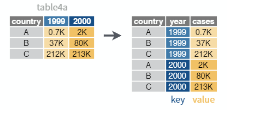

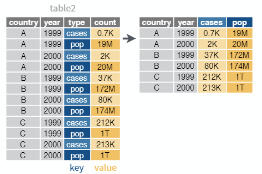

Veamos cada uno

### El gather()

La función **gather()** posee la siguiente estructura:

```r
gather(
  data,
  key = "key",
  value = "value",
  ...,
  na.rm = FALSE,
  convert = FALSE,
  factor_key = FALSE
)
```

Veamos una aplicación:

```r
datos <- tibble(
  time = as.Date('2009-01-01') + 0:9,
  Ejecutado = rnorm(10, 0, 1),
  Ajustado = rnorm(10, 0, 2),
  Inicial = rnorm(10, 0, 4)
)

datos
```

```
## # A tibble: 10 x 4
##    time       Ejecutado Ajustado Inicial
##    <date>         <dbl>    <dbl>   <dbl>
##  1 2009-01-01    0.637    1.67    -1.86
##  2 2009-01-02    1.25     0.829   -5.23
##  3 2009-01-03   -0.353   -3.49    -1.03
##  4 2009-01-04    0.556    1.22    -4.74
##  5 2009-01-05    0.300    1.07     0.317
##  6 2009-01-06   -0.299   -2.12    -5.71
##  7 2009-01-07    0.0611  -0.0496  -3.18
##  8 2009-01-08   -0.112    0.494   -0.704
##  9 2009-01-09    1.38    -1.36    -1.52
## 10 2009-01-10   -0.985    0.656    5.29
```

```r
# Forma 1

gather(datos, "presupuestos", "valores", -time)
```

```
## # A tibble: 30 x 3
##    time       presupuestos valores
##    <date>     <chr>          <dbl>
##  1 2009-01-01 Ejecutado     0.637
##  2 2009-01-02 Ejecutado     1.25
##  3 2009-01-03 Ejecutado    -0.353
##  4 2009-01-04 Ejecutado     0.556
##  5 2009-01-05 Ejecutado     0.300
##  6 2009-01-06 Ejecutado    -0.299
##  7 2009-01-07 Ejecutado     0.0611
##  8 2009-01-08 Ejecutado    -0.112
##  9 2009-01-09 Ejecutado     1.38
## 10 2009-01-10 Ejecutado    -0.985
## # ... with 20 more rows
```

```r
# Forma 2

datos %>% gather("stock", "price", -time)
```

```
## # A tibble: 30 x 3
##    time       stock       price
##    <date>     <chr>       <dbl>
##  1 2009-01-01 Ejecutado  0.637
##  2 2009-01-02 Ejecutado  1.25
##  3 2009-01-03 Ejecutado -0.353
##  4 2009-01-04 Ejecutado  0.556
##  5 2009-01-05 Ejecutado  0.300
##  6 2009-01-06 Ejecutado -0.299
##  7 2009-01-07 Ejecutado  0.0611
##  8 2009-01-08 Ejecutado -0.112
##  9 2009-01-09 Ejecutado  1.38
## 10 2009-01-10 Ejecutado -0.985
## # ... with 20 more rows
```

### El spread()

La función **spread()** posee la siguiente estructura:

```r
spread(
  data,
  key,
  value,
  fill = NA,
  convert = FALSE,
  drop = TRUE,
  sep = NULL)
```

Veamos una aplicación:

```r
stocks <- data.frame(
  time = as.Date('2009-01-01') + 0:9,
  X = rnorm(10, 0, 1),
  Y = rnorm(10, 0, 2),
  Z = rnorm(10, 0, 4)
)

stocks
```

```
##          time          X          Y         Z
## 1  2009-01-01 -1.2532359  2.9908331  2.568115
## 2  2009-01-02 -0.3351192  1.4077733  1.727960
## 3  2009-01-03  0.2500957 -0.2708417  1.210773
## 4  2009-01-04  0.8238337  0.9851507 -3.646207
## 5  2009-01-05 -1.0074052  1.5495568  1.938743
## 6  2009-01-06  1.1986667  2.2869860  2.275775
## 7  2009-01-07 -1.6273755 -1.4991621 -6.386094
## 8  2009-01-08  0.1577848  1.9870971 -7.946069
## 9  2009-01-09  0.1991142  0.9055034  7.684872
## 10 2009-01-10 -1.9937163 -1.3406450 -8.161437
```

```r
stocksm <- stocks %>% gather(stock, price, -time)

stocksm %>% spread(stock, price)
```

```
##          time          X          Y         Z
## 1  2009-01-01 -1.2532359  2.9908331  2.568115
## 2  2009-01-02 -0.3351192  1.4077733  1.727960
## 3  2009-01-03  0.2500957 -0.2708417  1.210773
## 4  2009-01-04  0.8238337  0.9851507 -3.646207
## 5  2009-01-05 -1.0074052  1.5495568  1.938743
## 6  2009-01-06  1.1986667  2.2869860  2.275775
## 7  2009-01-07 -1.6273755 -1.4991621 -6.386094
## 8  2009-01-08  0.1577848  1.9870971 -7.946069
## 9  2009-01-09  0.1991142  0.9055034  7.684872
## 10 2009-01-10 -1.9937163 -1.3406450 -8.161437
```

Veamos como ir de un gather() a un spread()

```r
#gather
stocksm <- stocks %>% gather(stock, price, -time)


#spread
stocksm %>% spread(stock, price)
```

```
##          time          X          Y         Z
## 1  2009-01-01 -1.2532359  2.9908331  2.568115
## 2  2009-01-02 -0.3351192  1.4077733  1.727960
## 3  2009-01-03  0.2500957 -0.2708417  1.210773
## 4  2009-01-04  0.8238337  0.9851507 -3.646207
## 5  2009-01-05 -1.0074052  1.5495568  1.938743
## 6  2009-01-06  1.1986667  2.2869860  2.275775
## 7  2009-01-07 -1.6273755 -1.4991621 -6.386094
## 8  2009-01-08  0.1577848  1.9870971 -7.946069
## 9  2009-01-09  0.1991142  0.9055034  7.684872
## 10 2009-01-10 -1.9937163 -1.3406450 -8.161437
```

Veamos otra forma como podemos modificar el sentido de la tabla.

```r
stocksm %>% spread(time, price)
```

```
##   stock 2009-01-01 2009-01-02 2009-01-03 2009-01-04 2009-01-05 2009-01-06
## 1     X  -1.253236 -0.3351192  0.2500957  0.8238337  -1.007405   1.198667
## 2     Y   2.990833  1.4077733 -0.2708417  0.9851507   1.549557   2.286986
## 3     Z   2.568115  1.7279601  1.2107730 -3.6462075   1.938743   2.275775
##   2009-01-07 2009-01-08 2009-01-09 2009-01-10
## 1  -1.627376  0.1577848  0.1991142  -1.993716
## 2  -1.499162  1.9870971  0.9055034  -1.340645
## 3  -6.386094 -7.9460695  7.6848715  -8.161437
```

Finalmente, las funciones **gather()** y **spread()** son complementarias. Se puede modicar el archivo de datos de un lado a otro.

Una referencia de la orientación de los datos, y sus dos funciones, es lo siguiente:

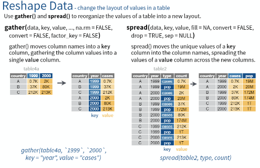

## Tratando los NA

Los **NA** o valores perdidos, siempre, siempre, …, siempre, serán un fastidio. Vimos que la función **summarise()** posee una forma de lidear con ellos, pero también se puede hacer frente modificando sus valores en el archivos de datos. Tres forms de manejar los **NA** o valores perdidos:

- **drop_na()**: elimina los **NA**. El problema es que al elimiar el **NA**, se eliminará la fila entera.
- **fill()**: rellena el **NA** con el valor más próximo arriba u abajo. Su forma es “fill(data, …, .direction = c(”down“,”up“,”downup“,”updown“))”
- replace_na(): remplace el **NA** por una valor. Su forma es “replace_na(data, replace, …)”

Veamos algunos ejemplos

### drop_na()

```r
library(tidyr)
df <- tibble(x = c(1, 2, NA), y = c("a", NA, "b"))
df
```

```
## # A tibble: 3 x 2
##       x y
##   <dbl> <chr>
## 1     1 a
## 2     2 <NA>
## 3    NA b
```

```r
df %>% drop_na()
```

```
## # A tibble: 1 x 2
##       x y
##   <dbl> <chr>
## 1     1 a
```

### fill()

```r
fill(data, ..., .direction = c("down", "up", "downup", "updown"))
```

```r
sales <- tibble::tribble(
  ~quarter, ~year, ~sales,
  "Q1",    2000,    66013,
  "Q2",      NA,    69182,
  "Q3",      NA,    53175,
  "Q4",      NA,    21001,
  "Q1",    2001,    46036,
  "Q2",      NA,    58842,
  "Q3",      NA,    44568,
  "Q4",      NA,    50197,
  "Q1",    2002,    39113,
  "Q2",      NA,    41668,
  "Q3",      NA,    30144,
  "Q4",      NA,    52897,
  "Q1",    2004,    32129,
  "Q2",      NA,    67686,
  "Q3",      NA,    31768,
  "Q4",      NA,    49094
)

sales %>% fill(year)
```

```
## # A tibble: 16 x 3
##    quarter  year sales
##    <chr>   <dbl> <dbl>
##  1 Q1       2000 66013
##  2 Q2       2000 69182
##  3 Q3       2000 53175
##  4 Q4       2000 21001
##  5 Q1       2001 46036
##  6 Q2       2001 58842
##  7 Q3       2001 44568
##  8 Q4       2001 50197
##  9 Q1       2002 39113
## 10 Q2       2002 41668
## 11 Q3       2002 30144
## 12 Q4       2002 52897
## 13 Q1       2004 32129
## 14 Q2       2004 67686
## 15 Q3       2004 31768
## 16 Q4       2004 49094
```

```r
tidy_pets <- tibble::tribble(
  ~rank, ~pet_type, ~breed,
  1L,        NA,    "Boston Terrier",
  2L,        NA,    "Retrievers (Labrador)",
  3L,        NA,    "Retrievers (Golden)",
  4L,        NA,    "French Bulldogs",
  5L,        NA,    "Bulldogs",
  6L,     "Dog",    "Beagles",
  1L,        NA,    "Persian",
  2L,        NA,    "Maine Coon",
  3L,        NA,    "Ragdoll",
  4L,        NA,    "Exotic",
  5L,        NA,    "Siamese",
  6L,     "Cat",    "American Short"
)

tidy_pets %>%
  fill(pet_type, .direction = "up")
```

```
## # A tibble: 12 x 3
##     rank pet_type breed
##    <int> <chr>    <chr>
##  1     1 Dog      Boston Terrier
##  2     2 Dog      Retrievers (Labrador)
##  3     3 Dog      Retrievers (Golden)
##  4     4 Dog      French Bulldogs
##  5     5 Dog      Bulldogs
##  6     6 Dog      Beagles
##  7     1 Cat      Persian
##  8     2 Cat      Maine Coon
##  9     3 Cat      Ragdoll
## 10     4 Cat      Exotic
## 11     5 Cat      Siamese
## 12     6 Cat      American Short
```

```r
squirrels <- tibble::tribble(
  ~group,    ~name,     ~role,     ~n_squirrels,
  1,      "Sam",    "Observer",   NA,
  1,     "Mara", "Scorekeeper",    8,
  1,    "Jesse",    "Observer",   NA,
  1,      "Tom",    "Observer",   NA,
  2,     "Mike",    "Observer",   NA,
  2,  "Rachael",    "Observer",   NA,
  2,  "Sydekea", "Scorekeeper",   14,
  2, "Gabriela",    "Observer",   NA,
  3,  "Derrick",    "Observer",   NA,
  3,     "Kara", "Scorekeeper",    9,
  3,    "Emily",    "Observer",   NA,
  3, "Danielle",    "Observer",   NA
)

squirrels %>%
  dplyr::group_by(group) %>%
  fill(n_squirrels, .direction = "downup") %>%
  dplyr::ungroup()
```

```
## # A tibble: 12 x 4
##    group name     role        n_squirrels
##    <dbl> <chr>    <chr>             <dbl>
##  1     1 Sam      Observer              8
##  2     1 Mara     Scorekeeper           8
##  3     1 Jesse    Observer              8
##  4     1 Tom      Observer              8
##  5     2 Mike     Observer             14
##  6     2 Rachael  Observer             14
##  7     2 Sydekea  Scorekeeper          14
##  8     2 Gabriela Observer             14
##  9     3 Derrick  Observer              9
## 10     3 Kara     Scorekeeper           9
## 11     3 Emily    Observer              9
## 12     3 Danielle Observer              9
```

### replace_na()

```r
df <- tibble(x = c(1, 2, NA), y = c("a", NA, "b"))
df
```

```
## # A tibble: 3 x 2
##       x y
##   <dbl> <chr>
## 1     1 a
## 2     2 <NA>
## 3    NA b
```

```r
df %>%
  replace_na(list(x = 0, y = "desconocido"))
```

```
## # A tibble: 3 x 2
##       x y
##   <dbl> <chr>
## 1     1 a
## 2     2 desconocido
## 3     0 b
```

## Separadores es una columna

Una columna puede realmente contener más de dos variable, y un separador es el que se interpone en la correcta definición de esta.

Podemos utilizar las funciones de separación para esto:

[figure not shown]

# Al finalizar la transformación de los datos…

Finalizado el proceso de transformación de los datos es que solemos hacer las consultas de la información que deseamos. Es como una tabla dinámica: esta se alimenta de un archivo para así saber la información requerida. En este caso, recurrimos al **summarise()** para así obtener la data de interés.

# Sitios de referencias

https://dplyr.tidyverse.org/

https://tidyr.tidyverse.org/

https://www.guru99.com/r-aggregate-function.html

https://www.datacamp.com/community/tutorials/pipe-r-tutorial

https://rsanchezs.gitbooks.io/rprogramming/content/chapter9/summarise.html

https://r4ds.had.co.nz/